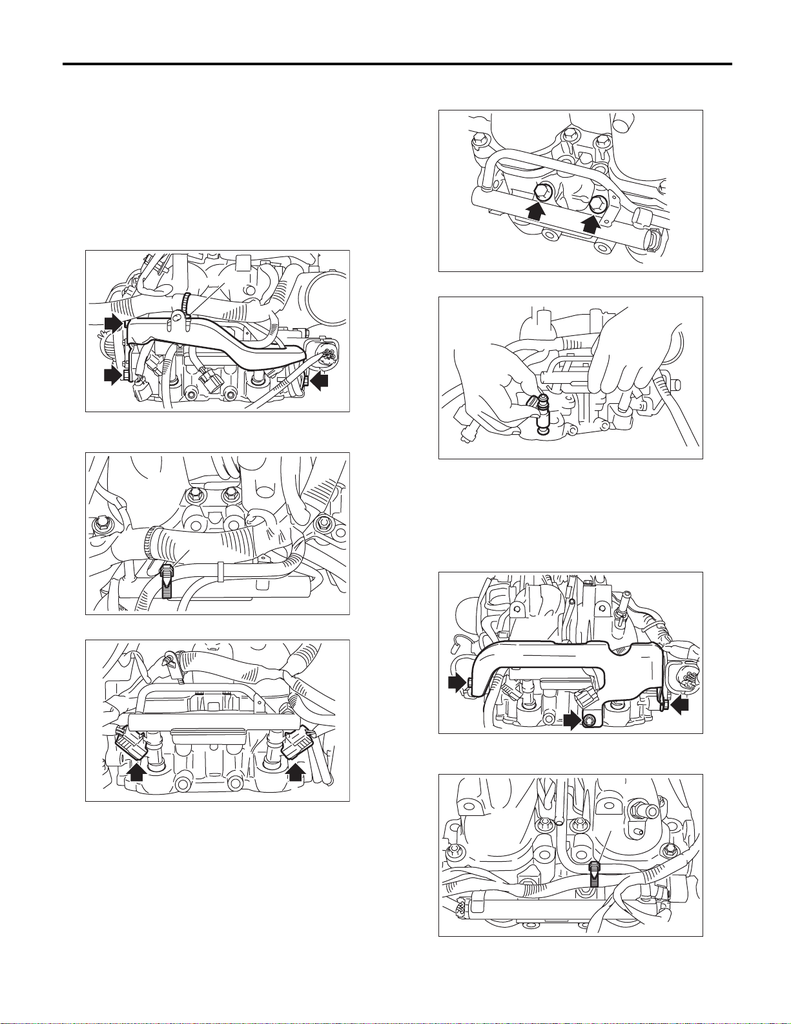

FU(STI)-43

Fuel Injector

FUEL INJECTION (FUEL SYSTEMS)

11.Fuel Injector

A: REMOVAL

1. RH SIDE

1) Disconnect the ground cable from battery.

2) Remove the intake manifold. <Ref. to FU(STI)-

17, REMOVAL, Intake Manifold.>

3) Remove clip (A) holding the engine harness to

the fuel pipe protector RH, and remove the fuel

pipe protector RH from the intake manifold.

4) Remove the harness band (A) which holds the

engine harness to the fuel injector pipe RH.

5) Disconnect the connector from fuel injector.

6) Remove the bolts which hold fuel injector pipe

RH.

7) Remove the fuel injector.

2. LH SIDE

1) Disconnect the ground cable from battery.

2) Remove the intake manifold. <Ref. to FU(STI)-

17, REMOVAL, Intake Manifold.>

3) Remove the fuel pipe protector LH from the in-

take manifold.

4) Remove the harness band (A) which holds the

engine harness to the fuel injector pipe LH.

FU-06575

(A)

FU-05919

(A)

FU-03568

FU-03512

FU-03513

FU-06591

FU-05920

(A)

15WRX_STI_US_EN.book 43 ページ ２０１５年２月１３日 金曜日 午前１１時２０分

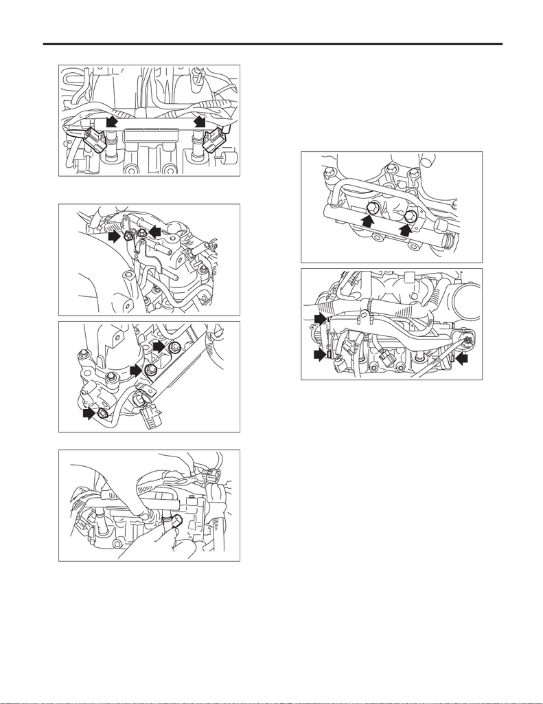

FU(STI)-44

Fuel Injector

FUEL INJECTION (FUEL SYSTEMS)

5) Disconnect the connector from fuel injector.

6) Remove the bolts which hold fuel injector pipe

LH.

7) Remove the fuel injector.

B: INSTALLATION

1. RH SIDE

Install in the reverse order of removal.

NOTE:

Use new O-rings, rubbers and seal rings.

Tightening torque:

19 N·m (1.9 kgf-m, 14.0 ft-lb)

FU-03508

FU-03594

FU-03595

FU-03527

FU-03512

FU-06583

15WRX_STI_US_EN.book 44 ページ ２０１５年２月１３日 金曜日 午前１１時２０分

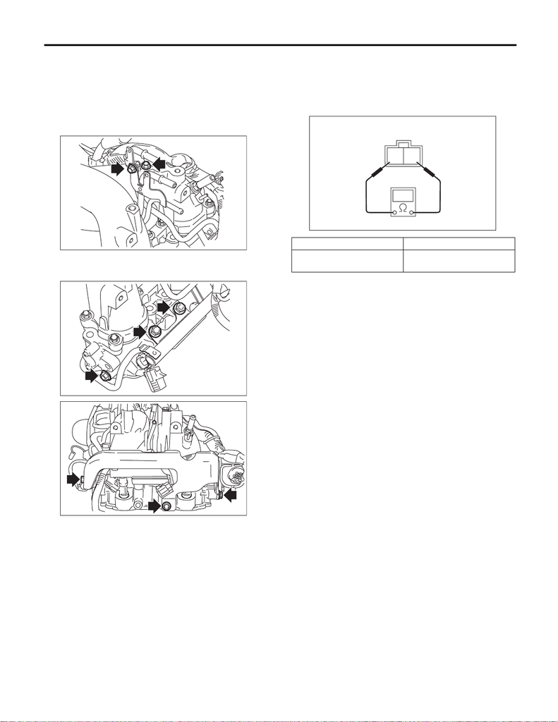

FU(STI)-45

Fuel Injector

FUEL INJECTION (FUEL SYSTEMS)

2. LH SIDE

Install in the reverse order of removal.

NOTE:

Use new O-rings, rubbers and seal rings.

Tightening torque:

6.4 N·m (0.7 kgf-m, 4.7 ft-lb)

Tightening torque:

19 N·m (1.9 kgf-m, 14.0 ft-lb)

C: INSPECTION

1) Check that the fuel injector has no deformation,

cracks or other damages.

2) Measure the resistance between fuel injector

terminals.

FU-03594

FU-03595

FU-06584

Terminal No. Standard

1 and 2

Approx. 12.0 Ω (when 20°C

(68°F))

2

1

EC-02428

15WRX_STI_US_EN.book 45 ページ ２０１５年２月１３日 金曜日 午前１１時２０分